# Biometry-02

### Performing ANOVA test on the data

### Performing ANOVA, because we have more than 2 sample

```r
rcf.lm<-lm(ocular_units~sugar_treatment)
one.way.anova = anova(rcf.lm)
one.way.anova
```

```
## Analysis of Variance Table
##
## Response: ocular_units
##                 Df Sum Sq Mean Sq F value    Pr(>F)
## sugar_treatment  4 1077.3 269.330  49.368 6.737e-16 ***
## Residuals       45  245.5   5.456
## ---
## Signif. codes:  0 '***' 0.001 '**' 0.01 '*' 0.05 '.' 0.1 ' ' 1
```

```r
anova_one_way1 <- aov(sugar$ocular_units~sugar$sugar_treatment)
anova_one_way1
```

```
## Call:
##    aov(formula = sugar$ocular_units ~ sugar$sugar_treatment)
##
## Terms:
##                 sugar$sugar_treatment Residuals
## Sum of Squares                1077.32    245.50
## Deg. of Freedom                     4        45
##
## Residual standard error: 2.335713
## Estimated effects may be unbalanced
```

From the initial anova test on the data, it can be observed that the p-value is much lower than the threshold p = 0.05. So that, it can be concluded that there is a significant difference between different sugar_tretments which is indicated by "*". We reject NULL and accpet alternative hypothesis.

```r
### Extracting residual values from the ANOVA test
res = anova_one_way1$residuals
```

# Diagnostics

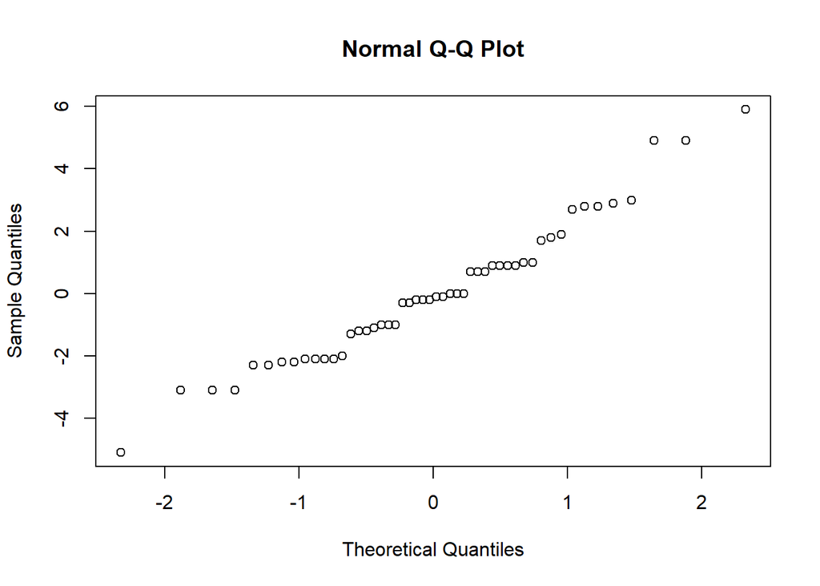

```r
qqnorm(rcf.lm$residuals)
```

```r
opar<-par(mfrow=c(2,2), mex=0.6,
mar=c(4,4,3,2)+0.3)
plot(rcf.lm, which=1:4)
```

[output not shown]

```r
par(opar)
```

### Testing Normality

### Ho: Data is normally distributed

### Ha: Data is not normally distributed

```r
shapiro.test(anova_one_way1$residuals)
```

```
##
##  Shapiro-Wilk normality test
##
## data:  anova_one_way1$residuals
## W = 0.96928, p-value = 0.2164
```

```r
bartlett.test(anova_one_way1$residuals~sugar_treatment)
```

```
##
##  Bartlett test of homogeneity of variances
##
## data:  anova_one_way1$residuals by sugar_treatment
## Bartlett's K-squared = 13.939, df = 4, p-value = 0.007494
```

Here, in bartlett test it is observed that the p value is smaller compared to threshold (0.05). Hence, we reject the NULL hypothesis and accpet the alternative hypothesis.Variances are not equal.

### As the bartlett failed to accpet the NULL hypothesis, we now log tranform the initial data.

### Log transforming:

```r
rcf.lm_transform <-lm(log10(ocular_units+1)~sugar_treatment)
one.way.anova_log_transform = anova(rcf.lm_transform)
one.way.anova_log_transform
```

```
## Analysis of Variance Table
##
## Response: log10(ocular_units + 1)
##                 Df   Sum Sq   Mean Sq F value    Pr(>F)
## sugar_treatment  4 0.048043 0.0120108  51.887 2.719e-16 ***
## Residuals       45 0.010417 0.0002315
## ---
## Signif. codes:  0 '***' 0.001 '**' 0.01 '*' 0.05 '.' 0.1 ' ' 1
```

```r
anova_one_way1_transform <- aov(log10(ocular_units+1)~sugar_treatment)
anova_one_way1_transform
```

```
## Call:
##    aov(formula = log10(ocular_units + 1) ~ sugar_treatment)
##
## Terms:
##                 sugar_treatment  Residuals
## Sum of Squares       0.04804325 0.01041655
## Deg. of Freedom               4         45
##
## Residual standard error: 0.01521443
## Estimated effects may be unbalanced
```

### Retrieving residuals from the transformed data

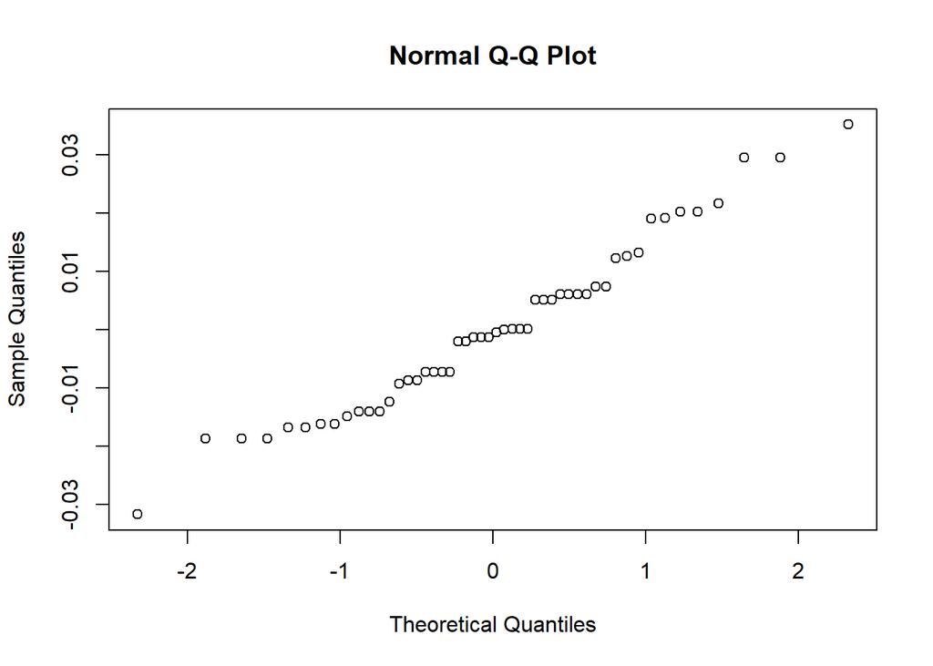

```r
res_transform = anova_one_way1_transform$residuals

# Diagnostics plots
qqnorm(anova_one_way1_transform$residuals)
```

```r
opar<-par(mfrow=c(2,2), mex=0.6,
mar=c(4,4,3,2)+0.3)
plot(rcf.lm, which=1:4)
```

[output not shown]

```r
par(opar)
```

### Testing for the normality and the variances on the log() transformed data

```r
shapiro.test(anova_one_way1_transform$residuals)
```

```
##
##  Shapiro-Wilk normality test
##
## data:  anova_one_way1_transform$residuals
## W = 0.97069, p-value = 0.2468
```

```r
bartlett.test(anova_one_way1_transform$residuals~sugar$sugar_treatment)
```

```
##
##  Bartlett test of homogeneity of variances
##
## data:  anova_one_way1_transform$residuals by sugar$sugar_treatment
## Bartlett's K-squared = 9.1353, df = 4, p-value = 0.05781
```

In both the cases, p value is higher compared to threshold. Hence, we accept the NULL hypothesis.

```r
# Pairwise comparison
# The one-way ANOVA test does not inform which group has a different mean. Instead, you can
# perform a Tukey test with the function TukeyHSD()

TukeyHSD(anova_one_way1)
```

```
##   Tukey multiple comparisons of means
##     95% family-wise confidence level
##
## Fit: aov(formula = sugar$ocular_units ~ sugar$sugar_treatment)
##
## $`sugar$sugar_treatment`
##                            diff       lwr       upr     p adj
## 2%.fructose-1%gluc.1%fruct  0.2 -2.768072  3.168072 0.9996878
## 2%.glucose-1%gluc.1%fruct   1.3 -1.668072  4.268072 0.7256157
## 2%.sucrose-1%gluc.1%fruct   6.1  3.131928  9.068072 0.0000052
## control-1%gluc.1%fruct     12.1  9.131928 15.068072 0.0000000
## 2%.glucose-2%.fructose      1.1 -1.868072  4.068072 0.8291029
## 2%.sucrose-2%.fructose      5.9  2.931928  8.868072 0.0000100
## control-2%.fructose        11.9  8.931928 14.868072 0.0000000
## 2%.sucrose-2%.glucose       4.8  1.831928  7.768072 0.0003242
## control-2%.glucose         10.8  7.831928 13.768072 0.0000000
## control-2%.sucrose          6.0  3.031928  8.968072 0.0000072
```

```r
TukeyHSD(anova_one_way1_transform)
```

```
##   Tukey multiple comparisons of means
##     95% family-wise confidence level
##
## Fit: aov(formula = log10(ocular_units + 1) ~ sugar_treatment)
##
## $sugar_treatment
##                                   diff          lwr        upr     p adj
## 2%.fructose-1%gluc.1%fruct 0.001386589 -0.017946922 0.02072010 0.9996004
## 2%.glucose-1%gluc.1%fruct  0.009432318 -0.009901192 0.02876583 0.6394269
## 2%.sucrose-1%gluc.1%fruct  0.042692144  0.023358633 0.06202565 0.0000012
## control-1%gluc.1%fruct     0.080521946  0.061188435 0.09985546 0.0000000
## 2%.glucose-2%.fructose     0.008045730 -0.011287781 0.02737924 0.7612047
## 2%.sucrose-2%.fructose     0.041305555  0.021972045 0.06063907 0.0000024
## control-2%.fructose        0.079135357  0.059801847 0.09846887 0.0000000
## 2%.sucrose-2%.glucose      0.033259826  0.013926315 0.05259334 0.0001255
## control-2%.glucose         0.071089628  0.051756117 0.09042314 0.0000000
## control-2%.sucrose         0.037829802  0.018496291 0.05716331 0.0000135
```

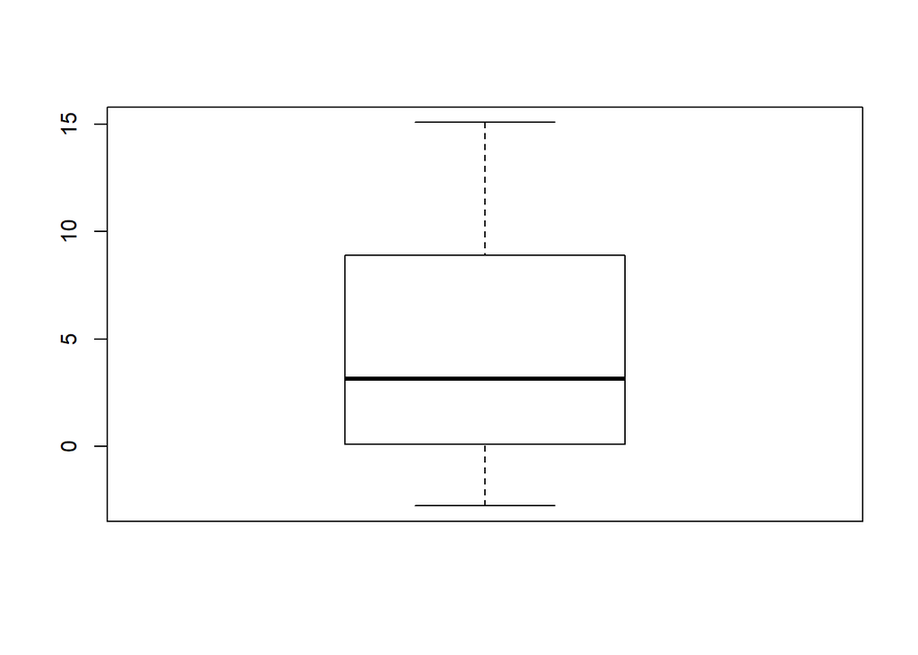

```r
boxplot(TukeyHSD(anova_one_way1))
```

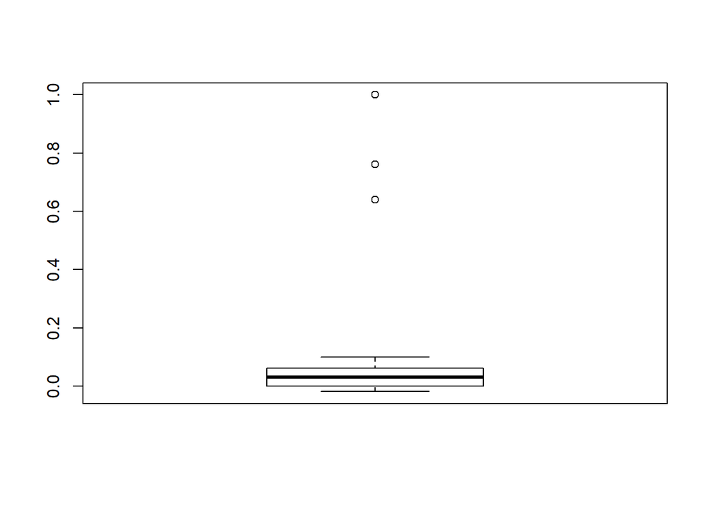

```r
boxplot(TukeyHSD(anova_one_way1_transform))
```

Looking at the last column, the significant differences to be reported in the present test is between the means of the groups : For non transformed data and transformed data showed similar p values 2%.sucrose-1%gluc.1%fruct control-1%gluc.1%fruct 2%.sucrose-2%.fructose control-2%.fructose 2%.sucrose-2%.glucose control-2%.glucose control-2%.sucrose

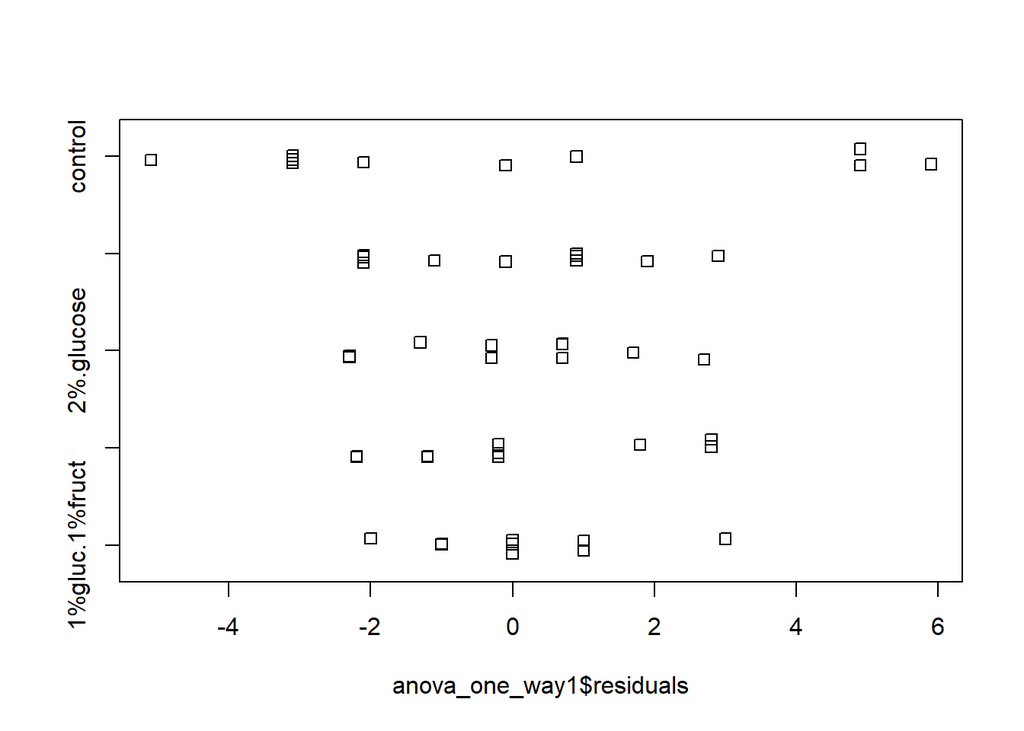

```r
stripchart(anova_one_way1$residuals~sugar$sugar_treatment, method = "jitter")
```

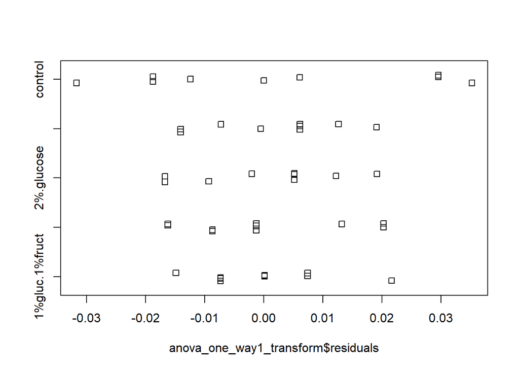

```r
stripchart(anova_one_way1_transform$residuals~sugar$sugar_treatment, method = "jitter")
```

##### Question 3:

### Hypothesis testing

# Ho: All the means are same accross the groups

# Ha: Atleast one difference betweeen the groups

```r
setwd("D:/Spring 2020/Biometry/Assignments/Homework_02")
snake = read.csv("snake.csv")
attach(snake)
summary(snake)
```

```
##             Population     Fat_g
##  ArmP            : 3   Min.   : 2.20
##  ArmP            :15   1st Qu.: 6.45
##  Lilos           :24   Median : 8.50
##  TerriaUp        : 4   Mean   :11.18
##  TerriaUp        :17   3rd Qu.:14.30
##                        Max.   :28.90
```

```r
levels(snake$Population)
```

```
## [1] "ArmP   "          "ArmP    "         "Lilos   "         "TerriaUp       "
## [5] "TerriaUp        "
```

[figure not shown]

```r
xbar <- tapply(Fat_g,Population,mean)
s <- tapply(Fat_g,Population, sd)
n <- tapply(Fat_g,Population,length)
sem <- s/sqrt(n)


stripchart(Fat_g ~ Population, vertical = T, pch = 19, data=snake,xlab = "Sugar Treatment", ylab = "Ocular Units", method = "jitter", jitter = 0.004)
arrows(1:5,xbar+sem,1:5,xbar-sem,angle=90,code=3,length=.1)
lines(1:5,xbar,pch=4,type="b",cex=2)
```

[figure not shown]

```r
xval<-barplot(xbar,ylim=c(0,85), xlab = "Sugar Treatment Type", ylab = "Ocular Units")
arrows(xval,xbar+sem,xval,xbar-sem,angle=90,code=3,length=.1)
```

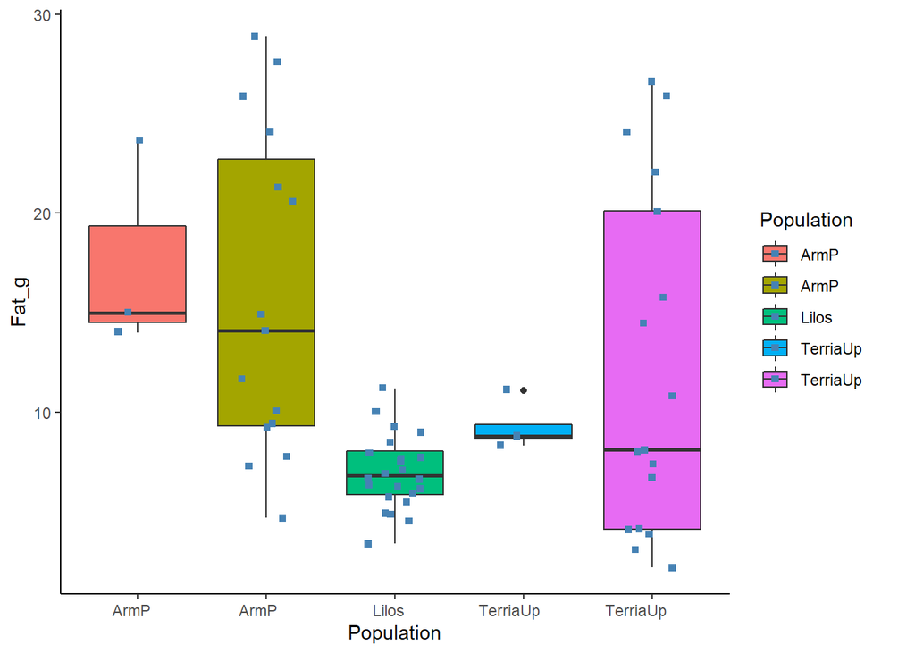

```r
library(ggplot2)
ggplot(snake, aes(x = Population, y = Fat_g, fill = Population)) + geom_boxplot() + geom_jitter(shape = 15,color = "steelblue",position = position_jitter(0.21)) + theme_classic()
```

```r
rcf.lm.snake<-lm(Fat_g ~ Population)
one.way.anova_snake = anova(rcf.lm.snake)
one.way.anova_snake
```

```
## Analysis of Variance Table
##
## Response: Fat_g
##            Df  Sum Sq Mean Sq F value   Pr(>F)
## Population  4  887.78 221.946  5.6806 0.000629 ***
## Residuals  58 2266.12  39.071
## ---
## Signif. codes:  0 '***' 0.001 '**' 0.01 '*' 0.05 '.' 0.1 ' ' 1
```

```r
anova_one_way1_snake <- aov(snake$Fat_g~snake$Population)
anova_one_way1_snake
```

```
## Call:
##    aov(formula = snake$Fat_g ~ snake$Population)
##
## Terms:
##                 snake$Population Residuals
## Sum of Squares          887.7848 2266.1183
## Deg. of Freedom                4        58
##
## Residual standard error: 6.25068
## Estimated effects may be unbalanced
```

```r
res_snake = anova_one_way1_snake$residuals
```

### Testing normality

### Here, I use Kolmogorov-Smirnov test and not shapiro, as samples are uneven in number

# The Kolmogorov-Smirnov test examines if scores are likely to follow some distribution in some population.

# Ho: Normal distribution

# Ha : Not normal distribution

```r
snake_ks = ks.test(Population,Fat_g)
snake_ks
```

```
##
##  Two-sample Kolmogorov-Smirnov test
##
## data:  Population and Fat_g
## D = 0.84127, p-value < 2.2e-16
## alternative hypothesis: two-sided
```

### Bartlett - Variances testing

```r
bartlett.test(Fat_g~Population)
```

```
##
##  Bartlett test of homogeneity of variances
##
## data:  Fat_g by Population
## Bartlett's K-squared = 43.315, df = 4, p-value = 8.901e-09
```

In Kolmogorov-Smirnov test and Bartlett test, as the p value is much lower compared to (p=0.05), we reject the NULL hypothesis. Hence, samples are not drawn from the sample population and variences are not equal.

### Transforming data,performing ANOVA and testing assumptions

```r
rcf.lm.snake_transform<-lm(log10(Fat_g+1) ~ Population)
one.way.anova_snake_transform = anova(rcf.lm.snake_transform)
one.way.anova_snake_transform
```

```
## Analysis of Variance Table
##
## Response: log10(Fat_g + 1)
##            Df Sum Sq  Mean Sq F value   Pr(>F)
## Population  4 0.9070 0.226751  5.1662 0.001251 **
## Residuals  58 2.5457 0.043891
## ---
## Signif. codes:  0 '***' 0.001 '**' 0.01 '*' 0.05 '.' 0.1 ' ' 1
```

```r
anova_one_way1_snake_transform <- aov(log10(Fat_g+1)~Population)
anova_one_way1_snake_transform
```

```
## Call:
##    aov(formula = log10(Fat_g + 1) ~ Population)
##
## Terms:
##                 Population Residuals
## Sum of Squares    0.907005  2.545683
## Deg. of Freedom          4        58
##
## Residual standard error: 0.209502
## Estimated effects may be unbalanced
```

```r
res_snake_transfom = anova_one_way1_snake_transform$residuals
```

### For Kolmogorov-Smirnov test

# Ho: Data is normal

# Ha: Data is not normal

### For Bartlett test of homogeneity of variances

# Ho: Equal variences

# Ha: Unequal variences

```r
ks.test(Population,res_snake_transfom)
```

```
##
##  Two-sample Kolmogorov-Smirnov test
##
## data:  Population and res_snake_transfom
## D = 1, p-value < 2.2e-16
## alternative hypothesis: two-sided
```

```r
bartlett.test(anova_one_way1_snake_transform$residuals~Population)
```

```
##
##  Bartlett test of homogeneity of variances
##
## data:  anova_one_way1_snake_transform$residuals by Population
## Bartlett's K-squared = 25.562, df = 4, p-value = 3.878e-05
```

Even for the transformed data, the p value remains same and do not meet the assumptions of normality and variences. We reject NULL and accept the alternative hypothesis.

# Pair wise comparision for non para metric data using Dunn’s Test of Multiple Comparisons Using Rank Sums

```r
library(PMCMR)
posthoc.kruskal.dunn.test(Fat_g, Population)
```

```
##
##  Pairwise comparisons using Dunn's-test for multiple
##                          comparisons of independent samples
##
## data:  Fat_g and Population
##
##                  ArmP    ArmP     Lilos    TerriaUp
## ArmP             1.0000  -        -        -
## Lilos            0.0847  0.0018   -        -
## TerriaUp         1.0000  1.0000   0.8272   -
## TerriaUp         0.6266  0.4983   0.4983   1.0000
##
## P value adjustment method: holm
```

Dunn’s-test, the pair wise comparision reveals that only Lilos and ArmP has significant differences as the p value is less than the threshold.

# Non-Parametric Analogs.

# Kruskal-Wallis test instead of one-way ANOVA.

# It is used when assumptions of one way ANOVA are not met.

# However, when using the Kruskal-Wallis Test, we do not have to make any of these assumptions.

# But,like most non-parametric tests, the Kruskal-Wallis Test is not as powerful as the ANOVA.

```r
# Ho: The samples (groups) have significant differences.
# Ha: At least one of the samples (groups) comes from a different population than the others and show no significant differences.
kruskal.test(Fat_g~Population,data=snake)
```

```
##
##  Kruskal-Wallis rank sum test
##
## data:  Fat_g by Population
## Kruskal-Wallis chi-squared = 17.656, df = 4, p-value = 0.00144
```

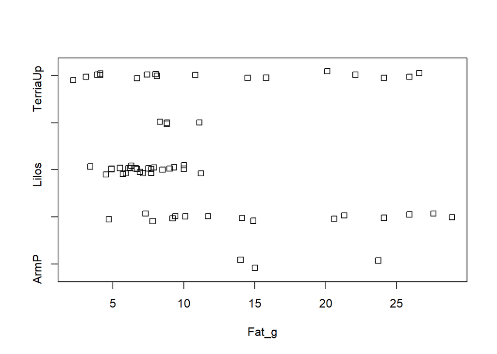

```r
## Data Visualization
stripchart(Fat_g~Population, method = "jitter")
```

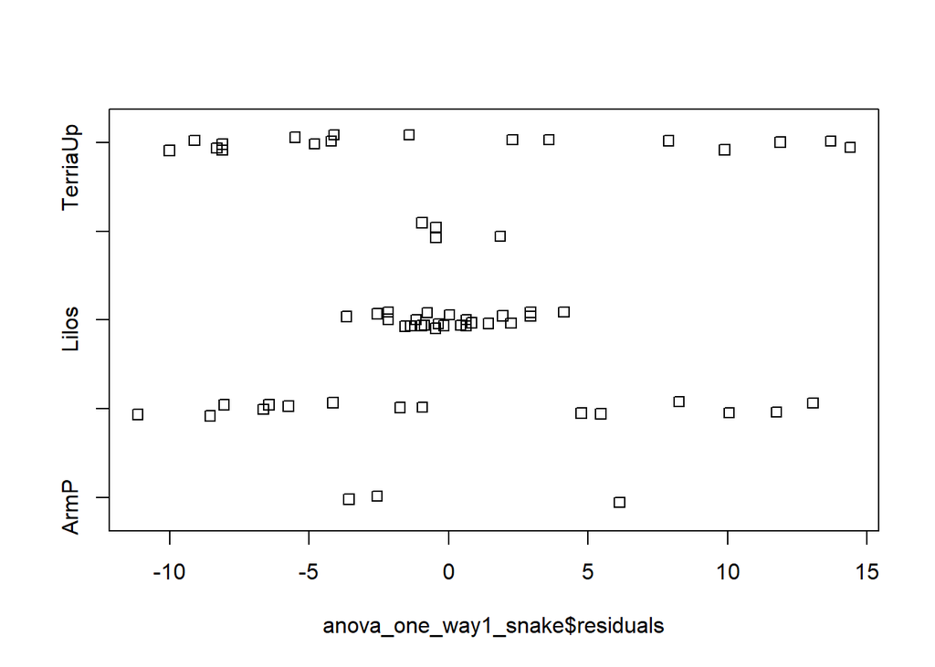

```r
stripchart(anova_one_way1_snake$residuals~Population, method = "jitter")
```

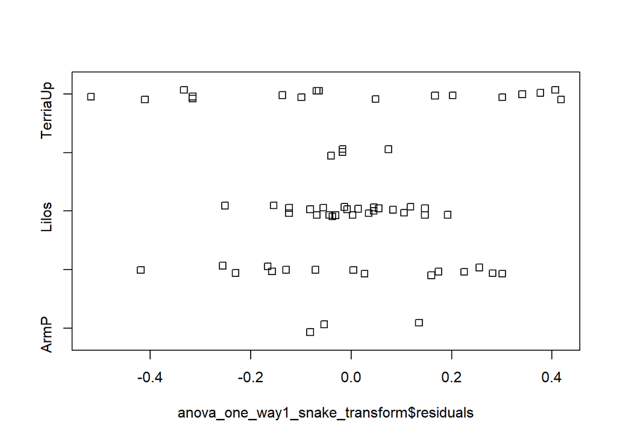

```r
stripchart(anova_one_way1_snake_transform$residuals~Population, method = "jitter")
```

From the above analysis, it can be concluded that threre are signifcant differences among the five samples.

### Question 4

## Hypothesis Testing

## Ho: Equal means among the species

## Ha: Atleast one difference among the spcecies

```r
setwd("D:/Spring 2020/Biometry/Assignments/Homework_02")
trees = read.csv("trees.csv")
attach(trees)
summary(trees)
```

```
##        SPP         Cells
##  Mahogany:25   Min.   : 0.000
##  Oak     :25   1st Qu.: 2.000
##  Teak    :25   Median : 4.000
##                Mean   : 4.947
##                3rd Qu.: 8.000
##                Max.   :13.000
```

```r
levels(trees$SPP)
```

```
## [1] "Mahogany" "Oak"      "Teak"
```

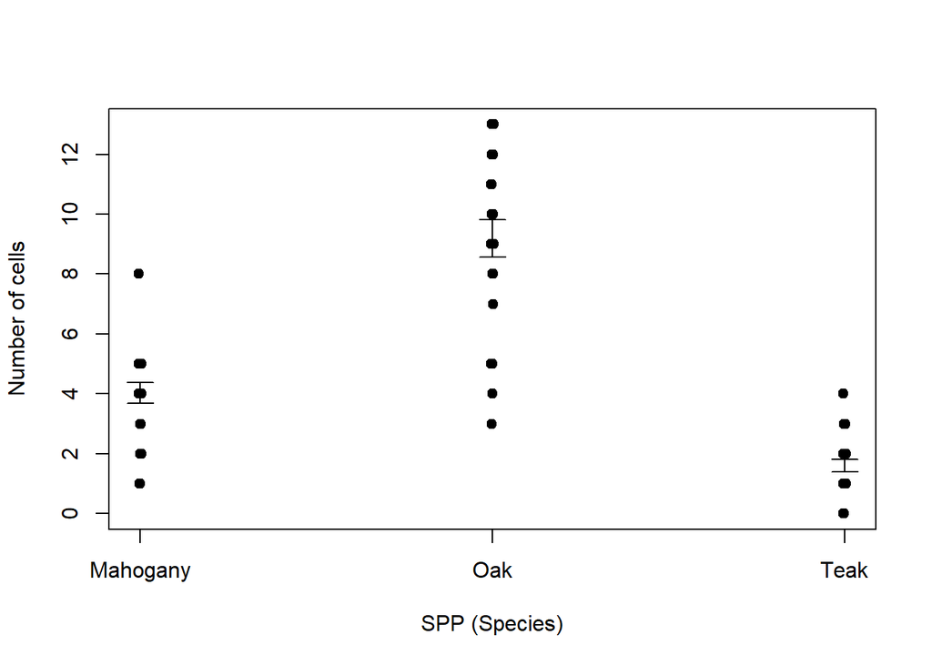

```r
xbar <- tapply(Cells,SPP,mean)
s <- tapply(Cells,SPP, sd)
n <- tapply(Cells,SPP,length)
sem <- s/sqrt(n)


stripchart(Cells ~ SPP, vertical = T, pch = 19, data=sugar,xlab = "SPP (Species)", ylab = "Number of cells", method = "jitter", jitter = 0.004)
arrows(1:5,xbar+sem,1:5,xbar-sem,angle=90,code=3,length=.1)
```

[figure not shown]

```r
#lines(1:5,xbar,pch=4,type="b",cex=2)

xval<-barplot(xbar,ylim=c(0,20), xlab = "SPP (Species)", ylab = "Ocular Units")
arrows(xval,xbar+sem,xval,xbar-sem,angle=90,code=3,length=.1)
```

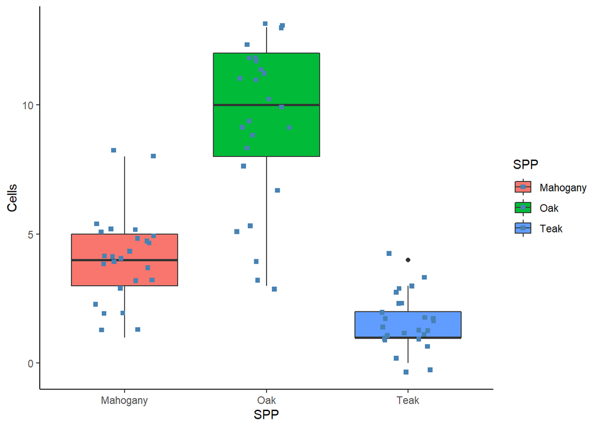

```r
library(ggplot2)
ggplot(trees, aes(x = SPP, y = Cells, fill = SPP)) + geom_boxplot() + geom_jitter(shape = 15,color = "steelblue",position = position_jitter(0.21)) + theme_classic()
```

Here, the numbers of cells for the Oak species are higher than Mahogany and Teak.

### Performing ANOVA test on the data

```r
rcf.lm.tree<-lm(Cells ~ SPP)
one.way.anova_trees = anova(rcf.lm.tree)
one.way.anova_trees
```

```
## Analysis of Variance Table
##
## Response: Cells
##           Df Sum Sq Mean Sq F value    Pr(>F)
## SPP        2 752.83  376.41   80.91 < 2.2e-16 ***
## Residuals 72 334.96    4.65
## ---
## Signif. codes:  0 '***' 0.001 '**' 0.01 '*' 0.05 '.' 0.1 ' ' 1
```

```r
anova_one_way1_trees <- aov(trees$Cells~trees$SPP)
anova_one_way1_trees
```

```
## Call:
##    aov(formula = trees$Cells ~ trees$SPP)
##
## Terms:
##                 trees$SPP Residuals
## Sum of Squares   752.8267  334.9600
## Deg. of Freedom         2        72
##
## Residual standard error: 2.156901
## Estimated effects may be unbalanced
```

```r
res_tree = anova_one_way1_trees$residuals
```

### Testing assumptions

### Shapiro - Normality testing

# Ho: Data is normal

# Ha: Data is not normal

### Bartlett - Variances testing

# Ho: Variences are equal

# Ha: Unequal variences

```r
shapiro.test(anova_one_way1_trees$residuals)
```

```
##
##  Shapiro-Wilk normality test
##
## data:  anova_one_way1_trees$residuals
## W = 0.9498, p-value = 0.004864
```

```r
bartlett.test(anova_one_way1_trees$residuals~SPP)
```

```
##
##  Bartlett test of homogeneity of variances
##
## data:  anova_one_way1_trees$residuals by SPP
## Bartlett's K-squared = 26.73, df = 2, p-value = 1.569e-06
```

Here, the p value for Shapiro and Bartlett is smaller than the threshold value ( p=0.05) and we reject the NULL hupothesis in both the tests

### Transforming data,performing ANOVA and testing assumptions

```r
rcf.lm.trees_transform<-lm(log10(Cells+1) ~ SPP)
one.way.anova_trees_transform = anova(rcf.lm.trees_transform)
one.way.anova_snake_transform
```

```
## Analysis of Variance Table
##
## Response: log10(Fat_g + 1)
##            Df Sum Sq  Mean Sq F value   Pr(>F)
## Population  4 0.9070 0.226751  5.1662 0.001251 **
## Residuals  58 2.5457 0.043891
## ---
## Signif. codes:  0 '***' 0.001 '**' 0.01 '*' 0.05 '.' 0.1 ' ' 1
```

```r
anova_one_way1_trees_transform <- aov(log10(Cells+1)~SPP)
anova_one_way1_trees_transform
```

```
## Call:
##    aov(formula = log10(Cells + 1) ~ SPP)
##
## Terms:
##                      SPP Residuals
## Sum of Squares  4.565156  2.174991
## Deg. of Freedom        2        72
##
## Residual standard error: 0.1738051
## Estimated effects may be unbalanced
```

```r
res_trees_transfom = anova_one_way1_trees_transform$residuals


shapiro.test(anova_one_way1_trees_transform$residuals)
```

```
##
##  Shapiro-Wilk normality test
##
## data:  anova_one_way1_trees_transform$residuals
## W = 0.91566, p-value = 0.0001004
```

```r
bartlett.test(anova_one_way1_trees_transform$residuals~SPP)
```

```
##
##  Bartlett test of homogeneity of variances
##
## data:  anova_one_way1_trees_transform$residuals by SPP
## Bartlett's K-squared = 0.58618, df = 2, p-value = 0.746
```

Here, we reject the NULL Hypothesis, which indicates that the data is not normal. But, we accept the NULL hypothesis in Bartlett test, which indicates that variences are equal

### Retrieving residuals from the transformed data

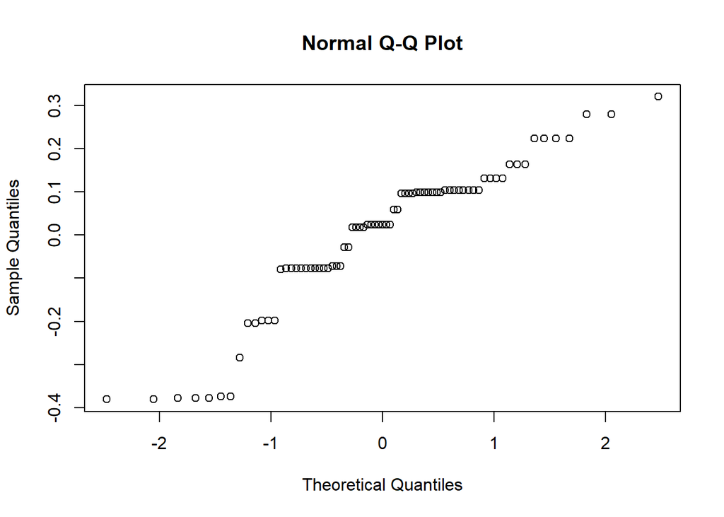

```r
res_trees_transform = anova_one_way1_trees_transform$residuals

# Diagnostics plots
qqnorm(anova_one_way1_trees_transform$residuals)
```

```r
opar<-par(mfrow=c(2,2), mex=0.6,
mar=c(4,4,3,2)+0.3)
plot(rcf.lm, which=1:4)
```

[output not shown]

```r
par(opar)
```

```r
## Pair wise comparision
TukeyHSD(anova_one_way1_trees)
```

```
##   Tukey multiple comparisons of means
##     95% family-wise confidence level
##
## Fit: aov(formula = trees$Cells ~ trees$SPP)
##
## $`trees$SPP`
##                diff       lwr        upr     p adj
## Oak-Mahogany   5.16  3.700042  6.6199581 0.0000000
## Teak-Mahogany -2.44 -3.899958 -0.9800419 0.0004421
## Teak-Oak      -7.60 -9.059958 -6.1400419 0.0000000
```

```r
TukeyHSD(anova_one_way1_trees_transform)
```

```
##   Tukey multiple comparisons of means
##     95% family-wise confidence level
##
## Fit: aov(formula = log10(Cells + 1) ~ SPP)
##
## $SPP
##                     diff        lwr        upr p adj
## Oak-Mahogany   0.3079419  0.1902971  0.4255867 1e-07
## Teak-Mahogany -0.2963492 -0.4139940 -0.1787044 2e-07
## Teak-Oak      -0.6042911 -0.7219359 -0.4866463 0e+00
```

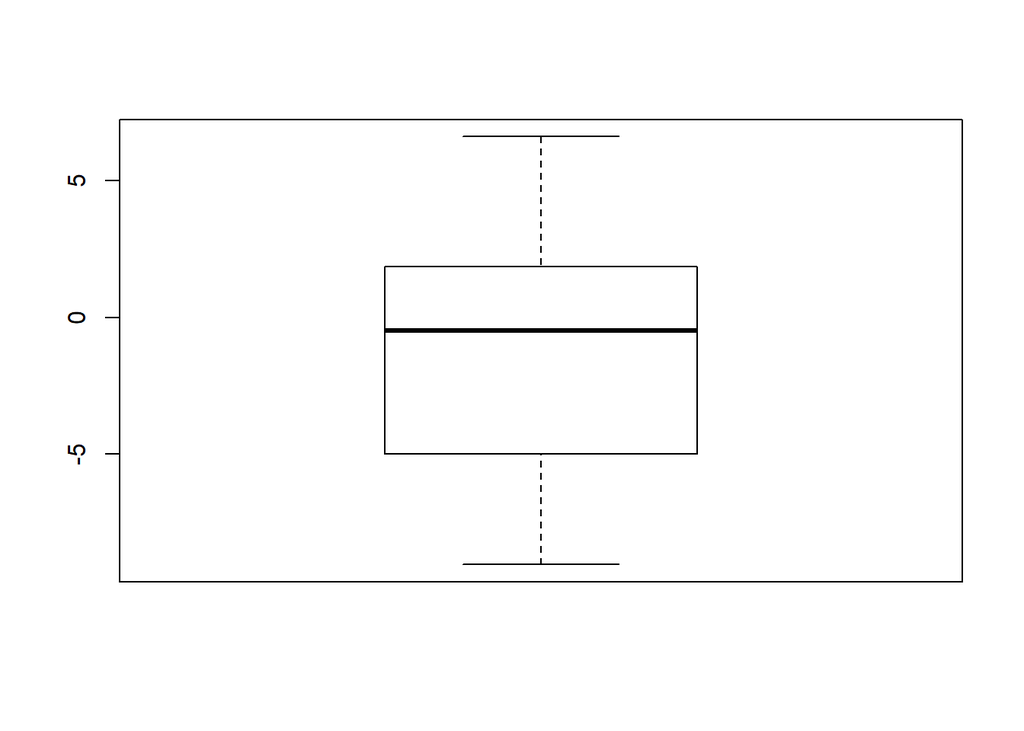

```r
boxplot(TukeyHSD(anova_one_way1_trees))
```

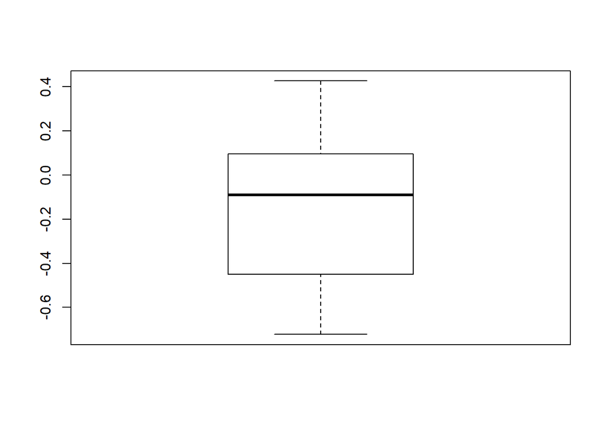

```r
boxplot(TukeyHSD(anova_one_way1_trees_transform))
```

Looking at the last column, the significant differences to be reported in the present test is between the means of the groups : For non transformed data and transformed data. All the pair wise comparisions have significant differenct differences as the p value is lower than threshod value.

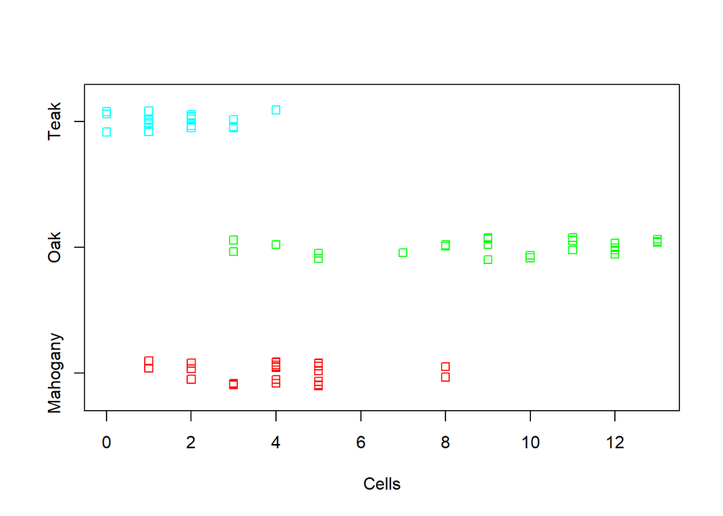

```r
stripchart(Cells~SPP, method = "jitter",col = c("red","green","cyan"))
```

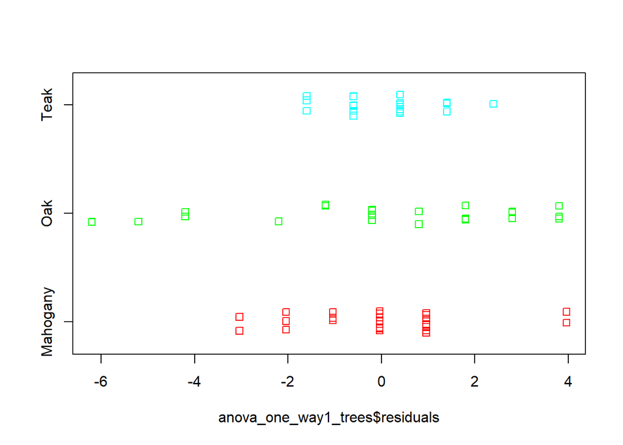

```r
stripchart(anova_one_way1_trees$residuals~SPP, method = "jitter",col = c("red","green","cyan"))
```

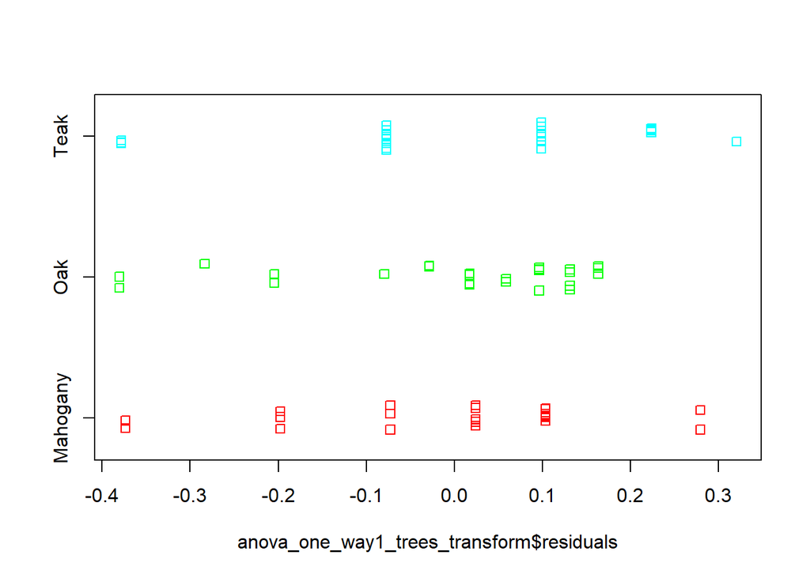

```r
stripchart(anova_one_way1_trees_transform$residuals~SPP, method = "jitter",col = c("red","green","cyan"))
```

Conclusin: Here, the numbers of cells are related to the wood density. Higher the number of cells for particular species, larger the wood density.SO, Oak species has the highest wood density and the Teak has the lowest.